# Epilepsy DEG와 겹치는 정도 차이에 따른 ASD with epilepsy 와 only ASD cell type의 분포 비교

김희연

# 1. 서론

Fig. S6H를 보면 ASD with epilepsy subgroup이 ASD only subgroup보다 DEG(Differentially expressed genes)가 전반적으로 epilepsy DEG와 더 겹친다.[^1] DEG가 얼만큼 겹치느냐가 phenotype에 어떻게 나타날까 궁금했다. ASD group은 주로 ASD specific DEG에게 영향을 크게 받으나 epilepsy DEG가 겹치는 것이 부차적으로 phenotype에 영향을 줄 것인지 궁금했다.

Fig. 2H에서 4번째로 Neuron differentiation의 -log10(q value) 값이 크다.그래서 Neuron differentiation를 볼 수 있는 cell type의 분포를 보려고 한다. 또한 Brainspan의 데이터를 가지고 ASD gene expression과 epilepsy gene expression 중 겹치는 gene의 expression을 비교하여 이 gene이 하는 역할이 cell differentiation에 영향을 미치는지 알아볼 것이다.

epilepsy DEG가 ASD group에 미치는 영향을 보기 위해서 ASD only subgroup의 cell type의 분포를 기준으로 epilepsy group과 ASD with epilepsy subgroup의 cell type 분포를 보고, 차이를 볼 것이다.  
시각화 하기 전, ASD with epilepsy subgroup이 기존 ASD only subgroup에서 epilepsy DEG에 의한 영향이 더해진 것이라고 가설을 세웠다. 또한 ASD의 두 subgroup의 DEG에서 겹치는 epilepsy DEG의 수 차이가 큰 3가지 세포에서는 그 DEG의 영향이 더 크게 cell 비율에 반영될 것이라고 생각했다. 이전에 세 subgroup의 brain cell의 수가 같다는 가정을 했지만, individual간의 세포 수 차이가 많이 나기 때문에 한 individual에서 특정 cell type이 차지하는 비율을 구해서 boxplot으로 subgroup끼리 비교할 것이다.

# 2. Data Visualization

```r
library(tidyverse)
```

```r
library(readxl)
library(dplyr)
library(ggplot2)
library(cowplot)
```

## 2.1 ASD with epilepsy subgroup와 ASD only subgroup의 cell 분포 비교

ASD subgroup을 기준으로 epilepsy patient와 ASD with epilepsy patient의 cell type을 비교한다. epilepsy subgroup과 ASD only subgroup의 boxplot을 그린 후, ASD의 두 subgroup의 분포를 차이를 잘 보기 위해서 두 subgroup의 boxplot을 그린다. cowplot으로 앞에서 그린 두 plot을 하나의 panel로 만든다. 또한 epilepsy DEG의 영향력을 보기 위해서 **y축의 cell의 순서를 ASD with epilepsy subgroup의 DEG가 epilepsy DEG와 겹치는 수가 많은 순서**로 바꾼다.

Data S1에서 ASD with epilepsy patient를 찾는다.

```r
ASD_sample = read_excel("C:\\Program Files\\biostatistics\\aav8130_Data-S1.xlsx", sheet = 2)

ASD_with_epilepsy = ASD_sample %>%
  filter(epilepsy == 'yes') %>%
  pull(Individual)
```

Data S2는 single-nuclei gene expression profiles로 gene들의 tSNE plot을 만드는 과정에서 추출된 각 cell의 cell type을 알 수 있다. 그래서 Data s2를 cell 분포를 구하는 데에 사용한 것이다.

Data S2를 load한 후 cell type을 확인한다.

```r
ASD = read_excel("C:\\Program Files\\biostatistics\\aav8130_Data-S2.xlsx", sheet = 1)
ep = read_excel("C:\\Program Files\\biostatistics\\aav8130_Data-S2.xlsx", sheet = 2)
unique(ASD$cluster)
```

```
##  [1] "OPC"              "Neu-mat"          "L2/3"             "IN-VIP"
##  [5] "IN-SST"           "Neu-NRGN-II"      "L5/6"             "L4"
##  [9] "L5/6-CC"          "Oligodendrocytes" "AST-PP"           "AST-FB"
## [13] "Neu-NRGN-I"       "Endothelial"      "IN-SV2C"          "IN-PV"
## [17] "Microglia"
```

```r
unique(ep$cluster)
```

```
##  [1] "Neu-mat"          "L5/6"             "AST-PP"           "Neu-NRGN"
##  [5] "L4"               "IN-SST"           "IN-VIP"           "IN-SV2C"
##  [9] "Oligodendrocytes" "L5/6-CC"          "L2/3"             "IN-PV"
## [13] "L2/3-epi"         "OPC"              "Microglia"        "AST-FB"
## [17] "Endothelial"
```

ASD의 cell type에는 Neu-NRGN-I,Neu-NRGN-II가 있고, epilepsy의 cell type에는 L2/3-epi가 있다. 나머지 cell의 종류는 같다. Neu-NRGN-I,Neu-NRGN-II는 NRGN-expressing neuron이다. ASD에서도 epilepsy와 같이 Neu-NRGN으로 하나로 묶겠다. L2/3-epi는 epidural L2/3으로 L2/3보다 더 바깥쪽에 있는 cell이다. 편의상 L2/3과 같다고 하겠다.

그리고 Data S2에서 ASD 환자 중에서 epilepsy를 가진 사람과 아닌 사람을 나눈다. 한 환자에서의 cell이 차지하는 비율을 ASD with epilepsy patient에서 모두 구한다.

이 과정을 epilepsy patient에서도 한다.

```r
ASD2 = ASD %>%
  mutate(cluster2 = ifelse(grepl('Neu-NRGN', cluster), 'Neu-NRGN', ASD$cluster)) %>%
  filter(diagnosis == 'ASD') %>%
  group_by(individual) %>%
  summarize("L2/3" = length(which(cluster2 == "L2/3"))/length(cluster2),
            'AST-FB' = length(which(cluster2 == "AST-FB"))/length(cluster2),
            'Microglia' = length(which(cluster2 == "Microglia"))/length(cluster2),
            'Endothelial' = length(which(cluster2 == "Endothelial"))/length(cluster2),
            'OPC' = length(which(cluster2 == "OPC"))/length(cluster2),
            'Neu-mat' = length(which(cluster2 == "Neu-mat"))/length(cluster2),
            'IN-SST' = length(which(cluster2 == "IN-SST"))/length(cluster2),
            'Oligodendrocytes' = length(which(cluster2 == "Oligodendrocytes"))/length(cluster2),
            'IN-VIP' = length(which(cluster2 == "IN-VIP"))/length(cluster2),
            'IN-SV2C' = length(which(cluster2 == "IN-SV2C"))/length(cluster2),
            'IN-PV' = length(which(cluster2 == "IN-PV"))/length(cluster2),
            'AST-PP' = length(which(cluster2 == "AST-PP"))/length(cluster2),
            'L5/6' = length(which(cluster2 == "L5/6"))/length(cluster2),
            'L5/6-CC' = length(which(cluster2 == "L5/6-CC"))/length(cluster2),
            'L4' = length(which(cluster2 == "L4"))/length(cluster2),
            'Neu-NRGN' = length(which(cluster2 == "Neu-NRGN"))/length(cluster2)) %>%
  gather(n1,n2,-individual) %>%
  mutate(epilepsy = ifelse(individual %in% ASD_with_epilepsy, 'ASD_with_epilepsy', 'ASD_only'))
ep2 = ep %>%
  mutate(cluster2 = gsub('-epi', '', ep$cluster)) %>%
  filter(diagnosis == 'Epilepsy') %>%
  group_by(individual) %>%
  summarize("L2/3" = length(which(cluster2 == "L2/3"))/length(cluster2),
            'AST-FB' = length(which(cluster2 == "AST-FB"))/length(cluster2),
            'Microglia' = length(which(cluster2 == "Microglia"))/length(cluster2),
            'Endothelial' = length(which(cluster2 == "Endothelial"))/length(cluster2),
            'OPC' = length(which(cluster2 == "OPC"))/length(cluster2),
            'Neu-mat' = length(which(cluster2 == "Neu-mat"))/length(cluster2),
            'IN-SST' = length(which(cluster2 == "IN-SST"))/length(cluster2),
            'Oligodendrocytes' = length(which(cluster2 == "Oligodendrocytes"))/length(cluster2),
            'IN-VIP' = length(which(cluster2 == "IN-VIP"))/length(cluster2),
            'IN-SV2C' = length(which(cluster2 == "IN-SV2C"))/length(cluster2),
            'IN-PV' = length(which(cluster2 == "IN-PV"))/length(cluster2),
            'AST-PP' = length(which(cluster2 == "AST-PP"))/length(cluster2),
            'L5/6' = length(which(cluster2 == "L5/6"))/length(cluster2),
            'L5/6-CC' = length(which(cluster2 == "L5/6-CC"))/length(cluster2),
            'L4' = length(which(cluster2 == "L4"))/length(cluster2),
            'Neu-NRGN' = length(which(cluster2 == "Neu-NRGN"))/length(cluster2)) %>%
  gather(n1,n2,-individual) %>%
  mutate(epilepsy = "epilepsy_only")
```

ASD only subgroup, epilepsy subgroup을 하나의 데이터로 만든다. cell 순서를 **ASD with epilepsy subgroup의 DEG가 epilepsy DEG와 많이 겹치는 cell 순**으로 바꿔서 boxplot을 그린다. ASD2로 아까와 같은 순서로 boxplot을 그린다. 그리고 두 개의 boxplot을 합친다.

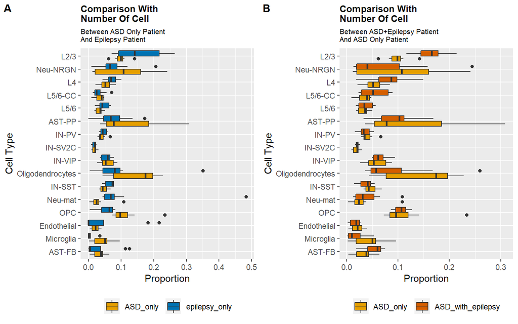

```r
p3 = rbind.data.frame(ep2,
                 ASD2 %>%
                   filter(epilepsy == 'ASD_only')) %>%
  mutate(cluster3 = factor(n1,
                           levels = c('AST-FB','Microglia','Endothelial','OPC','Neu-mat','IN-SST','Oligodendrocytes','IN-VIP','IN-SV2C','IN-PV','AST-PP','L5/6','L5/6-CC','L4', 'Neu-NRGN', 'L2/3'))) %>%
  ggplot(aes(cluster3, n2, fill = epilepsy)) +
  geom_boxplot(position = "dodge",  width = 0.8) +
  scale_fill_manual(values = c("#E69F00","#0072B2")) +
  coord_flip() +
  xlab("Cell Type") +
  ylab("Proportion") +
  labs(title = "Comparison With \nNumber Of Cell",
  subtitle =  "Between ASD Only Patient \nAnd Epilepsy Patient") +
  theme(legend.position="bottom",
        legend.title = element_blank(),
        plot.title = element_text(face='bold', size=10),
        plot.subtitle = element_text(size = 8))

 p4 = ASD2 %>%
  mutate(cluster3 = factor(n1,
                           levels = c('AST-FB','Microglia','Endothelial','OPC','Neu-mat','IN-SST','Oligodendrocytes','IN-VIP','IN-SV2C','IN-PV','AST-PP','L5/6','L5/6-CC','L4', 'Neu-NRGN', 'L2/3'))) %>%
  ggplot(aes(cluster3, n2, fill = epilepsy)) +
  geom_boxplot(position = "dodge",  width = 0.8) +
  scale_fill_manual(values = c("#E69F00","#D55E00")) +
  coord_flip() +
  labs(title = "Comparison With \nNumber Of Cell",
  subtitle = "Between ASD+Epilepsy Patient \nAnd ASD Only Patient") +
  xlab("Cell Type") +
  ylab("Proportion") +
  theme(legend.position="bottom",
        legend.title = element_blank(),
        plot.title = element_text(face='bold', size=10),
        plot.subtitle = element_text(size = 8))

plot_grid(p3, p4, labels = c('A', 'B'), label_size = 12)
```

A에서 boxplot의 median을 보면 epilepsy가 L2/3, L4, L5/6, IN-PV, IN-VIP, IN-SST, Neu-mat의 비율이 ASD only subgroup보다 높다. Neu-NRGN, L5/6-CC, AST-PP, Oligodendrocytes, OPC,Endothelial, Microglia, AST-FB의 비율은 epilepsy subgroup이 더 낮다. IN-SV2C는 육안으로 차이를 확인할 수 없다.

B에서 boxplot의 median을 보면 ASD with epilepsy subgroup은 ASD only subgroup보다 L2/3, L4, L5/6-CC, AST-PP,IN-VIP, Neu-mat, OPC, AST-FB의 비율이 높다. 나머지 Neu-NRGN, L5/6, IN-PV, Oligodedrocytes, IN-SST, Endothelial, Microglia의 비율은 ASD with epilepsy가 낮다. IN-SV2C는 거의 똑같아서 육안으로 차이를 확인할 수 없는 차이를 가지고 있다.

y축의 위에서 아래로 갈수록 겹치는 DEG 수가 적어진다. 하지만 cell type 비율 차이의 크기가 문제가 아니라 방향성조차도 겹치는 DEG 수와 관련이 없어 보인다. 그래서 이전에 했던 Neu-NRGN, L5/6, IN-PV를 특정해서 보는 data visualizaiton은 삭제하였다.

## 2.2 ASD의 gene expression과 epilepsy gene expression의 비교

이전의 시각화에서 epilepsy DEG와 겹치는 ASD DEG가 무엇이며, fold change가 얼마나 일어났는지를 몰랐고 그래서 epilepsy DEG에 영향을 받아 cell 비율이 바뀐 것인지도 확신할 수 없었다.그래서 원래는 ASD의 DEG와 epilepsy의 DEG를 비교하여 겹치는 gene과 fold change를 비교하려고 하였다. 하지만 epilepsy DEG를 찾지 못하였고, Brainsapn에서 Autism과 epilepsy의 developmental transcriptome을 비교해서 겹치는 gene의 expression을 비교할 것이다. gene expression이 다르면 이 gene이 하는 일에 따라 ASD와 epilepsy에서 차이가 나타는 것일 것이기 때문이다. 또한 이 차이가 ASD only와 ASD with epilepsy의 phenotype에 다른 점을 만들 수 있다.

`Brainspan`[^2]에서 epilepsy gene expression과 autism gene expression을 DFC(dorsolateral prefrontal cortex), VFC(ventrolateral prefrontal cortex), MFC(anterior (rostral) cingulate (medial prefrontal) cortex)에 특정 지어서 데이터를 다운로드하였다.

```r
epilepsy_gene = read_csv("C:\\Users\\김희연\\Downloads\\I1HAQN15YP11_0log2\\Rows.csv")
epilepsy_expression = read_csv("C:\\Users\\김희연\\Downloads\\I1HAQN15YP11_0log2\\Expression.csv",col_names = FALSE)
Autism_gene = read_csv("C:\\Users\\김희연\\Downloads\\4Q94P21IIM11_0log2\\Rows.csv")
Autism_expression = read_csv("C:\\Users\\김희연\\Downloads\\4Q94P21IIM11_0log2\\Expression.csv", col_names = FALSE)
```

epilepsy gene과 epilepsy expression을 합친다. 그리고 epilepsy의 gene의 이름을 저장해서 Autism gene과 겹치는 것이 있는지 찾을 것이다.

```r
names(epilepsy_expression)[1] = "id"

epilepsy_gene2 = merge(x = epilepsy_expression, epilepsy_gene %>% select(`gene-symbol`,id),by = "id" )

ep_gene = epilepsy_gene2 %>%
  pull(`gene-symbol`)
```

Autism gene과 expression을 합친다. 그리고 아까 저장한 epilepsy gene과 겹치는 gene을 찾는다. 겹치는 gene은 DCX, TSC2, TSC1, ATP10A이다.

```r
names(Autism_expression)[1] = "id"

Autism_gene2 = merge(x = Autism_expression, y =Autism_gene %>% select(`gene-symbol`, id) ,by = "id")

a = Autism_gene2 %>%
  filter(`gene-symbol` %in% ep_gene) %>%
  gather(n1, n2, -`gene-symbol`) %>%
  slice_tail(n=2096) %>%
  mutate(disease="Autism")

head(a)
```

```
##   gene-symbol n1     n2 disease
## 1         DCX X2 5.4424  Autism
## 2        TSC2 X2 3.1812  Autism
## 3        TSC1 X2 1.6245  Autism
## 4      ATP10A X2 0.1431  Autism
## 5         DCX X3 6.4481  Autism
## 6        TSC2 X3 3.5633  Autism
```

epilepsy에서 이 gene들의 expression을 구하고, epilepsy와 autism expression 데이터프레임을 합친다.

```r
b = epilepsy_gene2 %>%
  filter(`gene-symbol`%in% c("DCX","TSC2","TSC1","ATP10A")) %>%
  gather(n1,n2, -`gene-symbol`) %>%
  slice_tail(n=408) %>%
  mutate(disease="epilepsy")

final_df = rbind.data.frame(a, b)
```

이 데이터 프레임의 boxplot을 그리고 분포를 볼 수 있게 violin plot도 같이 그린다.

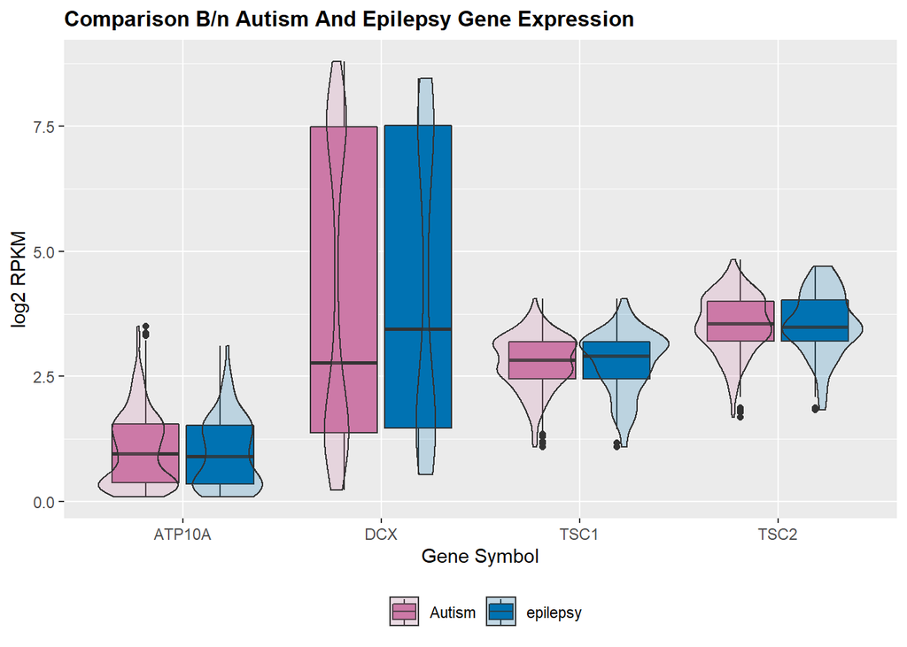

```r
final_df %>%
  ggplot(aes(`gene-symbol`, n2, fill = disease)) +
  geom_boxplot() +
  geom_violin(alpha=0.2) +
  scale_fill_manual(values = c("#CC79A7","#0072B2")) +
  labs(title = "Comparison B/n Autism And Epilepsy Gene Expression ") +
  xlab("Gene Symbol") +
  ylab("log2 RPKM") +
  theme(legend.position="bottom",
        legend.title = element_blank(),
        plot.title = element_text(face='bold', size=12))
```

RPKM stands for “Reads Per Kilobase of transcript per Million mapped reads”. This formula is commonly used to normalise next-generation sequencing data, accounting for varying sequencing depth (number of total reads per sample) and transcript length (more reads mapping to a longer genomic region).[^3]

즉, RPKM은 gene이 얼마나 발현했는지 read depth와 gene length로 nomralize 시켜서 보여준다.

다른 gene의 expression은 거의 같은 수준이지만, DCX만 Autism과 epilepsy에 차이가 있다. epilepsy에서 DCX가 더 많이 발현한다.

각각의 gene에 대한 설명을 GeneCards[^4]에서 찾았다.

> ATP10A : ATP10A (ATPase Phospholipid Transporting 10A (Putative)) is a Protein Coding gene. Diseases associated with ATP10A include Angelman Syndrome Due To Imprinting Defect In 15Q11-Q13 and Angelman Syndrome. Among its related pathways are Transport of glucose and other sugars, bile salts and organic acids, metal ions and amine compounds and Ion channel transport. Gene Ontology (GO) annotations related to this gene include nucleotide binding and cation-transporting ATPase activity. An important paralog of this gene is ATP10D.

> DCX : DCX (Doublecortin) is a Protein Coding gene. Diseases associated with DCX include Lissencephaly, X-Linked, 1 and Band Heterotopia. Among its related pathways are Neuroscience and L1CAM interactions. Gene Ontology (GO) annotations related to this gene include protein kinase binding and calmodulin binding. An important paralog of this gene is CAMK4.

> TSC1 : TSC1 (TSC Complex Subunit 1) is a Protein Coding gene. Diseases associated with TSC1 include Tuberous Sclerosis 1 and Lymphangioleiomyomatosis. Among its related pathways are Respiratory electron transport, ATP synthesis by chemiosmotic coupling, and heat production by uncoupling proteins. and TBC/RABGAPs. Gene Ontology (GO) annotations related to this gene include binding and chaperone binding.

> TSC2 : TSC2 (TSC Complex Subunit 2) is a Protein Coding gene. Diseases associated with TSC2 include Focal Cortical Dysplasia, Type Ii and Lymphangioleiomyomatosis. Among its related pathways are Translation Translation regulation by Alpha-1 adrenergic receptors and Monoamine Transport. Gene Ontology (GO) annotations related to this gene include protein homodimerization activity and binding. An important paralog of this gene is RALGAPA1.

DCX의 설명에 직접적인 Neuroscience가 언급되어있다. DCX의 역할을 더 알아보니 DCX gene은 Doublecortin을 coding 하고 있다. 줄여서 DCX라고 하는데 이 DCX는 Neuronal migration을 일으키는 protein이다.[^5]

> Doublecortin (DCX) is a microtubule-associated protein expressed by neuronal precursor cells and immature neurons in embryonic and adult cortical structures. Neuronal precursor cells begin to express DCX while actively dividing, and their neuronal daughter cells continue to express DCX for 2–3 weeks as the cells mature into neurons. Downregulation of DCX begins after 2 weeks, and occurs at the same time that these cells begin to express NeuN, a marker for mature neurons.[^6]

이 설명에 따르면 DCX의 분포가 위 아래에 몰려 있는 걸 이해할 수 있다. 많이 발현된 cell들은 cell dividing이 일어나는 immature 상태이고, 적게 발현된 cell은 mature cell인 것이다.

DCX gene은 Xq23에 위치한다.[^7] 그래서 성별에 따라 cell type의 분포에 차이가 있지 않을까 추측한다.

그렇다면 보충하기 위해 무엇이 필요할까?

1. epilepsy DEG 데이터가 필요하다. ASD DEG에서 처럼 어떤 epilepsy DEG가 얼마나 dysregulated 되어있는지 알면 지금보다 더 나아질 것이다. ASD DEG와 비교해서 겹치는 DEG가 epilepsy와 ASD group에서 upregulation되었는지, downregulation되었는지 확인을 하면 더 확실하게 cell 비율을 ASD with epilepsy subgroup과 ASD only subgroup을 비교할 수 있을 것이다.
2. 그럼에도 문제가 생길 수 있는 부분은 dysregulation된 gene들이 neuron differentiation에 영향을 미미하게 미치는 경우 cell 분포가 특별한 특징을 나타내지 않을 수 있다. 그렇다면 cell 분포가 아닌 epilepsy의 정도을 비교해볼 수 있다.
3. neurolignin-3을 knockout 시킨 Autism mouse model을 이용한다[^8]. Downregulation된 epilepsy DEG 중 하나를 knockout 시켜서 knockout 시키지 않은 Autism mouse와 epilepsy가 일어나는지 일어나지 않는지를 통해서 영향력을 살펴본다. 이런 실험을 epilepsy DEG를 바꿔가며 반복하면 epilepsy DEG가 phenotype에 미치는 영향을 조금이나마 알 수 있을 것 같다.

그리고 2.2 Data visualization을 이용하여 성별에 따른 Autism과 epilepsy cell type의 분포를 살펴보는 연구를 할 수 있다. 이는 epilepsy가 autism보다 더 DCX gene을 많이 발현하는 것이 어떤 차이를 일으키는지 보는 것이다.

# 3. 결론

시각화를 하기 전에 ASD with epilepsy subgroup이 기존 ASD only subgroup에서 epilepsy DEG에 의해 영향이 더해진 것이라고 가설을 세웠다. 또한 ASD의 두 subgroup의 epilepsy DEG와 겹치는 DEG의 수 차이가 큰 3가지 세포에서는 그 DEG의 영향이 더 크게 cell 비율 변화에 반영될 것이라고 생각했다.

부족한 점들을 보완하기 위해서 epilepsy DEG 데이터를 추가로 사용하여 cell 분포를 비교하는 방법을 제시했고, 그 방법도 cell 분포에 경향성을 확인할 수 없을 수 있다는 한계점이 있기 때문에 epilepsy 정도를 비교하는 것을 생각해봤다. 직접적으로 Autism mouse model을 사용해서 gene을 knockout 시켜서 epilepsy에 미치는 영향을 확인하는 방법도 제시했다. 그리고 추가로 한 시각화에서 연결해서 Autism과 epilepsy 화자의 성별에 따른 cell 분포의 차이를 볼 수 있을 것이라고 추측했다.

# 4. Reference

1. Dmitry Velmeshev, Lucas Schirmer, Diane Jung, Maximilian Haeussler, Yonatan Perez, Simone Mayer1, Aparna Bhaduri, Nitasha Goyal, David H. Rowitch, Arnold R. Kriegstein, Single-cell genomics identifies cell type–specific molecular changes in autism, *Nature* **364**, 685-689(2019).
2. Brown JP, Couillard-Després S, Cooper-Kuhn CM, Winkler J, Aigner L, Kuhn HG, Transient expression of doublecortin during adult neurogenesis, *J. Comp. Neurol* **467**, 1–10 (2003).
3. Shireene Kalbassi, Sven O. Bachmann, Ellen Cross, Victoria H. Roberton and Stéphane J. Baudouin, Male and Female Mice Lacking Neuroligin-3 Modify the Behavior of Their Wild-Type Littermates, *eNeuro* Vol. 4, Issue 4, (2017)

# 5. Feedback

epilespy DEG를 추가해서 실제로 fold change를 ASD epilepsy와 비교하는 것이 좋을 것 같다는 피드백을 받았다. 그래서 epilepsy DEG를 찾아보았지만 결국 찾지 못했다. 대신 Autism과 epilepsy gene expression을 비교해서 DcX gene expression이 다르다는 결과에 이르렀다. DCX gene이 하는 역할을 찾아서 결국 neuron differentiation에 영향을 미칠 것으로 결론을 내렸다.

그리고 한 사람당 가지는 세포 수가 천차만별로 다르다는 비판을 수용해서 individual당 세포가 차지하는 비율을 구해서 boxplot으로 나타냈다.

2.1 시각화의 y축 cell 순서에 대해서 이전에도 언급을 했지만 보기 어렵다는 비판을 수용해서 해당 언급을 강조했다.

[^1]: https://science.sciencemag.org/content/364/6441/685
[^2]: https://www.brainspan.org/rnaseq/search/index.html
[^3]: https://www.ebi.ac.uk/training/online/glossary/rpkm
[^4]: https://www.genecards.org/
[^5]: https://www.ncbi.nlm.nih.gov/gene?cmd=retrieve&dopt=default&list_uids=1641
[^6]: https://pubmed.ncbi.nlm.nih.gov/14574675/
[^7]: https://www.genenames.org/data/gene-symbol-report/#!/hgnc_id/2714
[^8]: https://www.eneuro.org/content/4/4/ENEURO.0145-17.2017